# ggplot2: Box Plots

2016-04-21

# Introduction

This is the 9th post in the series **Elegant Data Visualization with ggplot2**. In the previous [post](https://rsquaredacademy.github.io/blog/post/ggplot2-line-graphs/), we learnt how to build line charts. In this post, we will focus on boxplots.

We will continue to use the ecommerce data. You can download it from [here](https://github.com/rsquaredacademy/datasets/blob/master/web.csv) or import directly using the readr package.

## Simple Box Plot

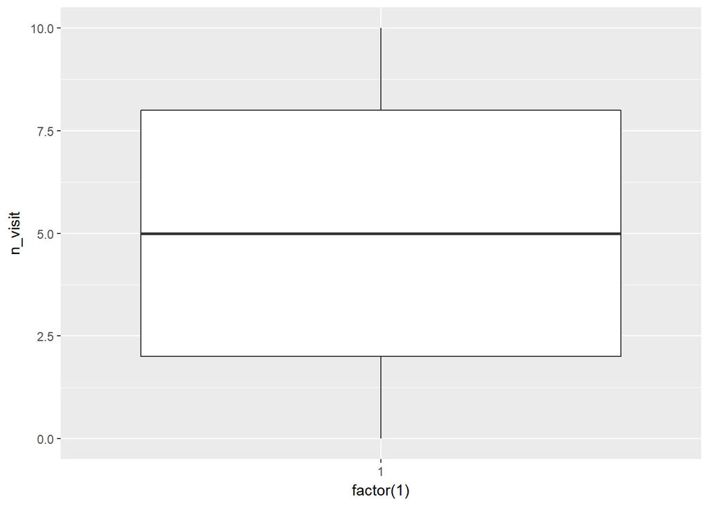

```r
ggplot(ecom) +
  geom_boxplot(aes(x = factor(1), y = n_visit))
```

Now we need to mention something for X axis and hence we use the number 1. If we do not mention anything, ggplot2 will return an error. You can generally use any categorical variable for the X axis. Below is an example:

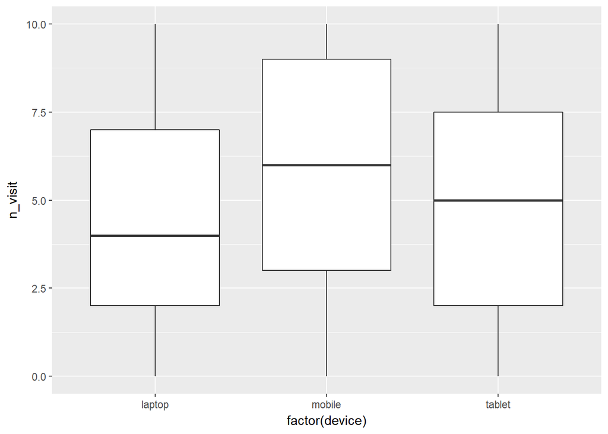

```r
ggplot(ecom) +
  geom_boxplot(aes(x = factor(device), y = n_visit))
```

If you want horizontal boxplots, use `coord_flip()`.

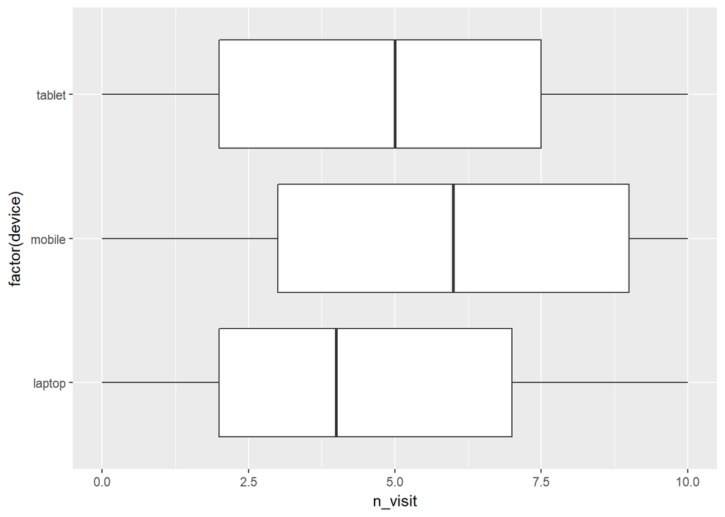

```r
ggplot(ecom) +
  geom_boxplot(aes(x = factor(device), y = n_visit)) +
  coord_flip()
```

## Notch

Notches are used to compare groups; if the notches of two boxes do not overlap, this suggests that the medians are significantly different.

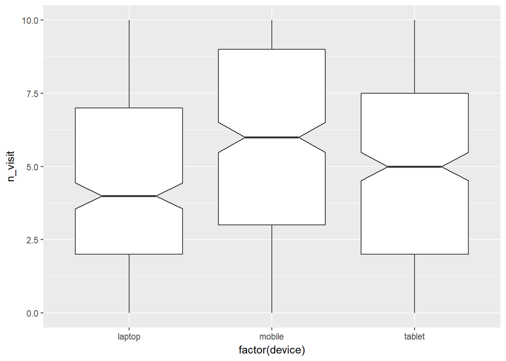

```r
ggplot(ecom) +
  geom_boxplot(aes(x = factor(device), y = n_visit),
               notch = TRUE)
```

## Jitter

Overlay points on boxplots.

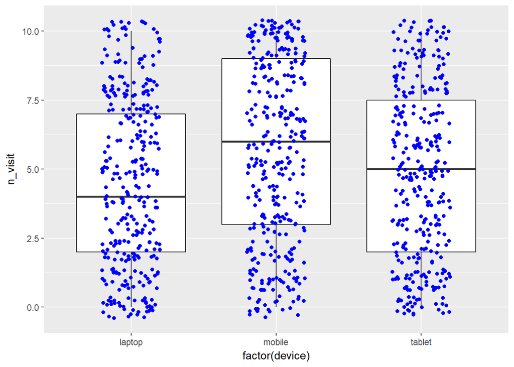

```r
ggplot(ecom, aes(x = factor(device), y = n_visit)) +
  geom_boxplot() +
  geom_jitter(width = 0.2, color = 'blue')
```

## Outliers

### Color

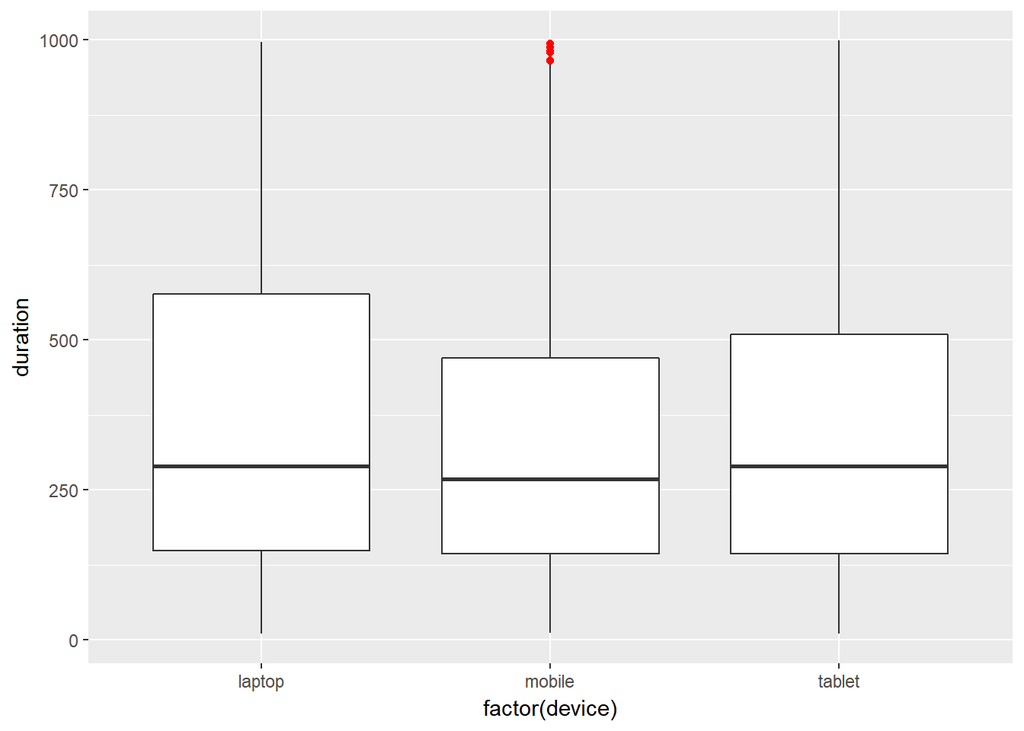

```r
ggplot(ecom) +
  geom_boxplot(aes(x = factor(device), y = duration),
               outlier.color = 'red')
```

## Shape

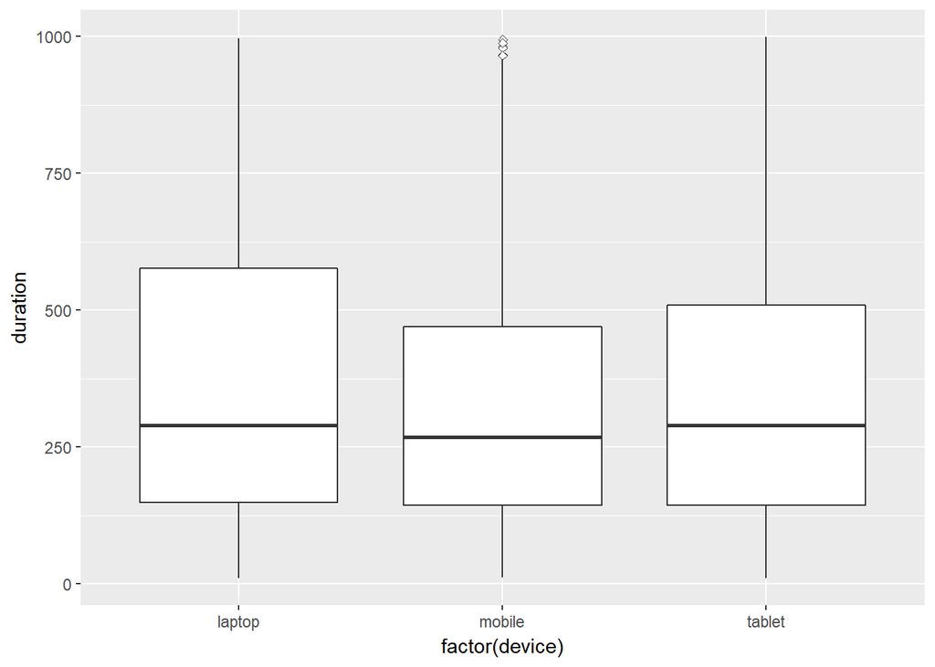

```r
ggplot(ecom) +
  geom_boxplot(aes(x = factor(device), y = duration),
               outlier.shape = 23)
```

Let us extend the Y axis and see if the ouliers appear more legible.

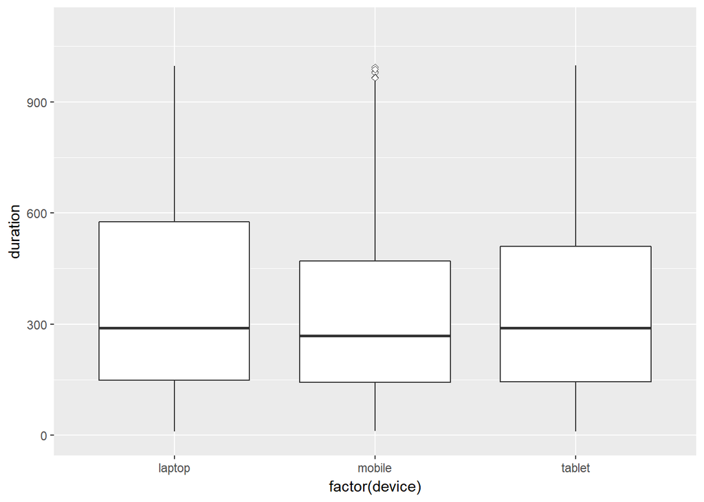

```r
ggplot(ecom) +
  geom_boxplot(aes(x = factor(device), y = duration),
               outlier.shape = 23) +
  expand_limits(y = c(0, 1100))
```

## Size

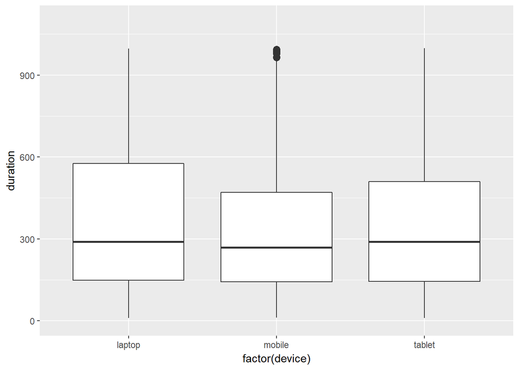

```r
ggplot(ecom) +
  geom_boxplot(aes(x = factor(device), y = duration),
               outlier.size = 3) +
  expand_limits(y = c(0, 1100))
```

Increasing the size is not very useful.

## Alpha

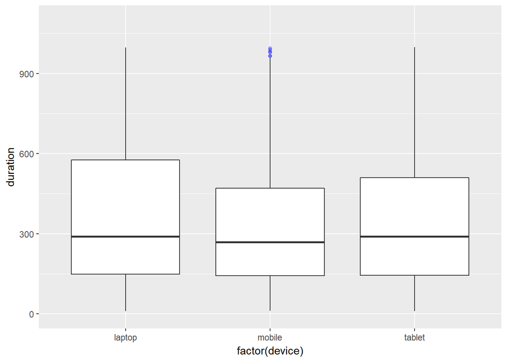

```r
ggplot(ecom) +
  geom_boxplot(aes(x = factor(device), y = duration),
               outlier.color = 'blue', outlier.alpha = 0.3) +
  expand_limits(y = c(0, 1100))
```

## Box Color

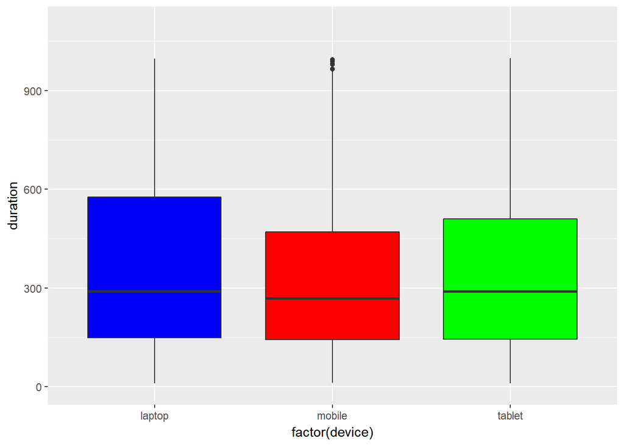

```r
ggplot(ecom) +
  geom_boxplot(aes(x = factor(device), y = duration),
               fill = c('blue', 'red', 'green')) +
  expand_limits(y = c(0, 1100))
```

Map box color to variable.

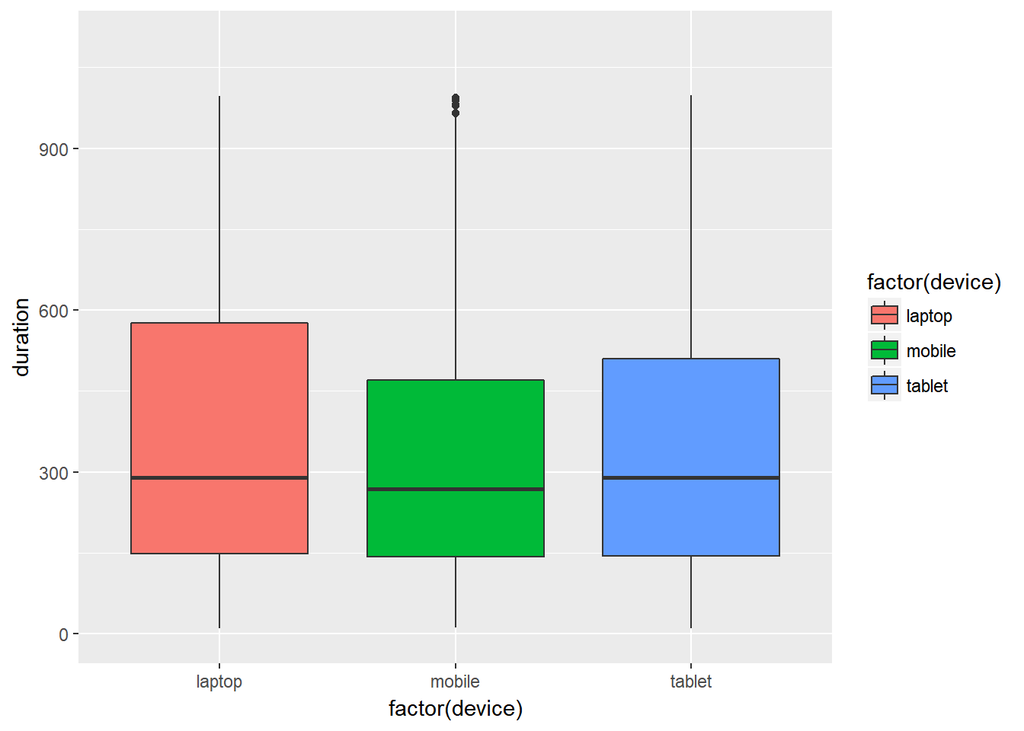

```r
ggplot(ecom) +
  geom_boxplot(aes(x = factor(device), y = duration,
               fill = factor(device))) +
  expand_limits(y = c(0, 1100))
```

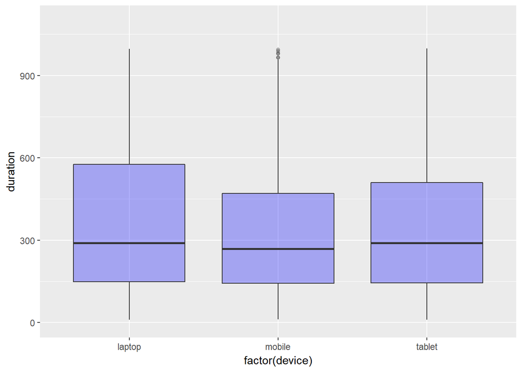

```r
ggplot(ecom) +
  geom_boxplot(aes(x = factor(device), y = duration),
               fill = 'blue', alpha = 0.3) +
  expand_limits(y = c(0, 1100))
```

## Line Color

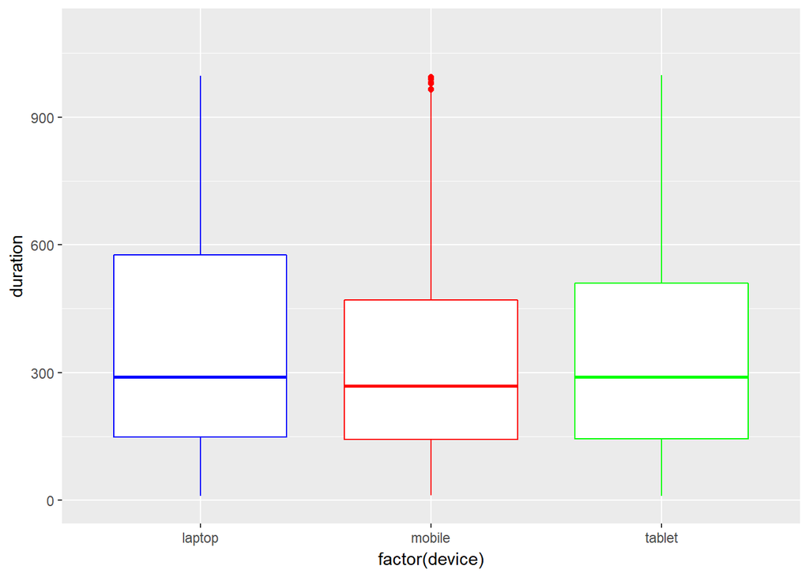

```r
ggplot(ecom) +
  geom_boxplot(aes(x = factor(device), y = duration),
               color = c('blue', 'red', 'green')) +
  expand_limits(y = c(0, 1100))
```

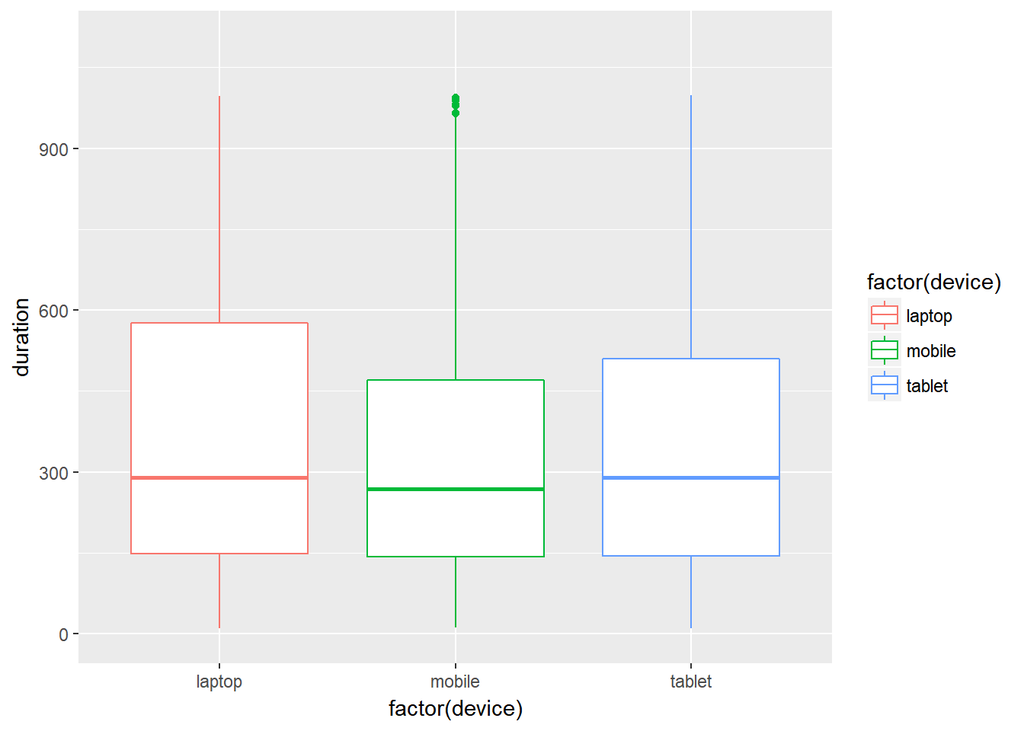

```r
ggplot(ecom) +
  geom_boxplot(aes(x = factor(device), y = duration,
               color = factor(device))) +
  expand_limits(y = c(0, 1100))
```

## Line Width

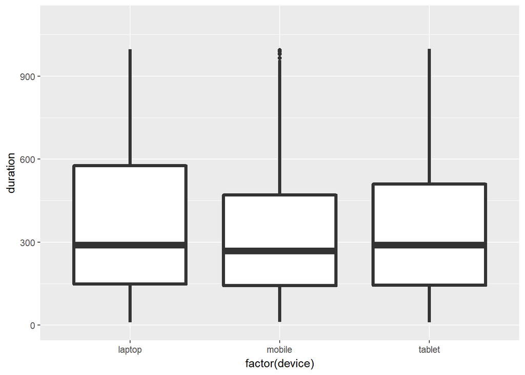

```r
ggplot(ecom) +
  geom_boxplot(aes(x = factor(device), y = duration),
               size = 1.5) +
  expand_limits(y = c(0, 1100))
```

## Line Type

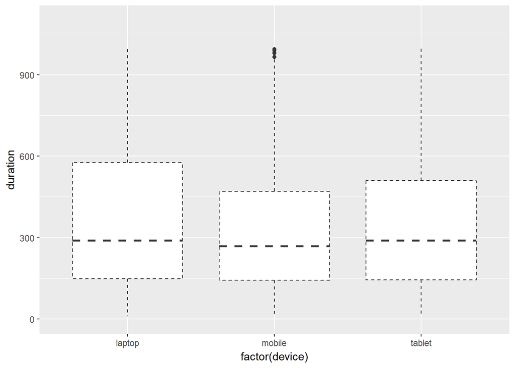

```r
ggplot(ecom) +
  geom_boxplot(aes(x = factor(device), y = duration),
               linetype = 2) +
  expand_limits(y = c(0, 1100))
```

## Summary

In this post, we learnt to:

- build box plots
- modify outlier color, shape, size etc.
- modify box color
- modify box line color, size and line type

In the next [post](https://rsquaredacademy.github.io/blog/post/ggplot2-bar-plots/), we will learn to build bar plots.